# Simulation2

**Mengqi Liu**

**Jun 16, 2023**

**Recap:**

- $N$: number of samples one time.
- $M$: number of bins.
- H0: $X\perp \!\!\! \perp Y \mid Z$, H1: $X\not \! \perp \!\!\! \perp Y \mid Z$
- Methods:
  - "Cor_kernel" is the method put forward in "Local permutation tests for conditional independence" and I revised it a little bit to make it suitable for continuous $X,Y,Z$ according to page 20 of "Minimax Optimal Conditional Independence Testing"(which is also one of cited paper of the former).
  - "Cor_kernel_2": I revised the method "Cor_kernel" to be two-sided. (I also found it weird to make one-side test as $P(T^{\textrm{permutation}}\geq T)$ in page 8 of "Local permutation tests for conditional independence") text
  - "Linear_reg": regress $Y$ on $X,Z$ and take the *absolute* coefficient of $X$ as the test statistic.
  - "Double_reg": regress $Y$ on $Z$ and regress $X$ on $Z$ separately. Take the *absolute* correlation between residuals from two linear regressions as the test statistic.
- $\alpha=0.05$

## H0

$N=100, Z\sim \textrm{Unif}([0,10))$, $M \in \{2, 4, 6, 10, 25, 50\}$.

- normal: $N(Z, 1)$
- normal_large: $N(Z, 10)$
- normal_small: $N(Z, 0.1)$
- chi: $\chi^2(\lceil Z \rceil))$
- t: $t(1)+Z$
- exp: $\textrm{exp}(\frac{1}{Z})$
- uni: $\textrm{Unif}([Z-1, Z+1])$
- poi: $\textrm{Poisson}(Z)$
- skewed_normal: $N(Z, 2)$, skewness=$-5$
- skewed_t: std_dev = $2$, loc = $Z$, skewness = $5$

```python
import numpy as np
import pandas as pd
import matplotlib.pyplot as plt
```

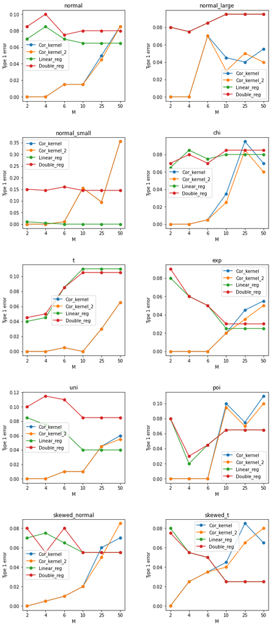

```python
types = ["normal", "normal_large", "normal_small", "chi", "t", "exp", "uni",
        "poi", "skewed_normal", "skewed_t"]
plt.figure(figsize=(10,25))
plt.subplots_adjust(wspace=.4, hspace=.4)
for t in range(len(types)):
    plt.subplot(5, 2, t+1)
    result = pd.read_csv("./results/result_null_"+types[t]+".csv", index_col=0)
    plt.plot(result.T, '-o')
    plt.xlabel("M")
    plt.ylabel("Type 1 error")
    plt.legend(result.index)
    plt.title(types[t])
plt.show()
```

**It's hard to say which method is better. But generally covariance kernel based methods (first two methods) perform well when $M$ is small and linear regression based methods perform well when $M$ is large.**

## H1

$N=100, Z\sim \textrm{Unif}([0,10))$, $M \in \{2, 4, 6, 10, 25, 50\}$.

- normal: $N\left([Z, Z], \begin{pmatrix} 1 & 0.5 \\ 0.5 & 1 \\ \end{pmatrix}\right)$
- normal_large: $N\left([Z, Z], \begin{pmatrix} 10 & 5 \\ 5 & 10 \\ \end{pmatrix}\right)$
- normal_small: $N\left([Z, Z], \begin{pmatrix} 0.1 & 0.05 \\ 0.05 & 0.1 \\ \end{pmatrix}\right)$
- uni: $\textrm{Unif}([Z-1, Z+1] \times [Z-1, Z+1])$
- skewed_normal: $N\left([Z, Z], \begin{pmatrix} 1 & 0.5 \\ 0.5 & 1 \\ \end{pmatrix}\right)$, skewness = $[5, -5]$

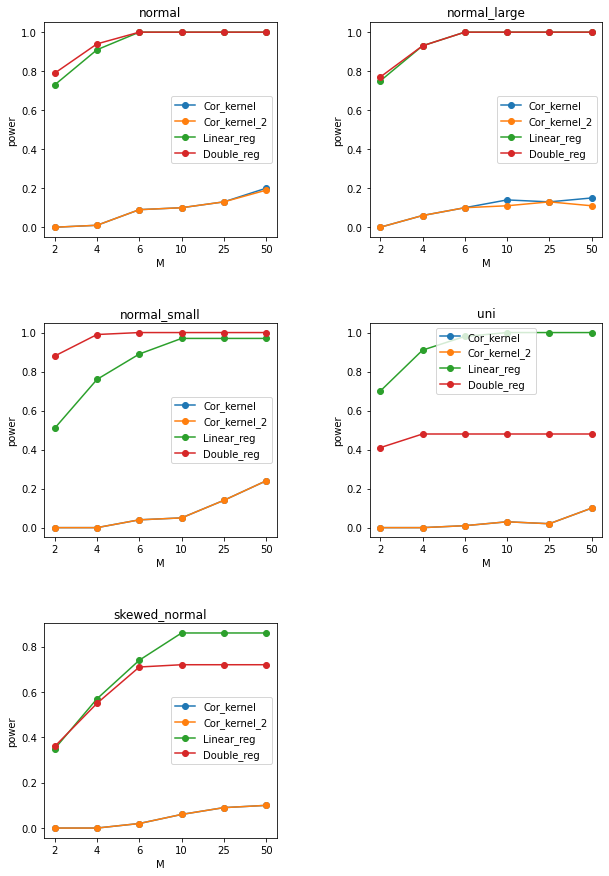

```python
types = ["normal", "normal_large", "normal_small", "uni", "skewed_normal"]
plt.figure(figsize=(10,15))
plt.subplots_adjust(wspace=.4, hspace=.4)
for t in range(len(types)):
    plt.subplot(3, 2, t+1)
    result = pd.read_csv("./results/result_h1_"+types[t]+".csv", index_col=0)
    plt.plot(result.T, '-o')
    plt.xlabel("M")
    plt.ylabel("power")
    plt.legend(result.index)
    plt.title(types[t])
plt.show()
```

**Linear regression based methods obviously have larger power with varying $M$. The performance of controlling type-1 error of covariance kernel based methods may be due to their conservatice instincts.**

## Simple graphical model: markov chain

**Problems:**

1. How to generate fully connected graph?
   - Don't know how to initialize and stop...
   - Here I instead use markov chain for naive try, where $Nvar$ means number of variables. Adjacent variables are dependent given other variables while separate variables are independent given other variables.
1. Here I use pairwise test pattern but how could we decide the direction for a DAG?
1. How to compute bins for multi-value z’s?
   - Clustering? Here I use kmeans++.

Test each pair of variables with $N=100$ and $M=10$. The rates of refusing null hypothesis are shown as below. **Obviously linear regression based method perform well with distinct color on the subdiagonals.**

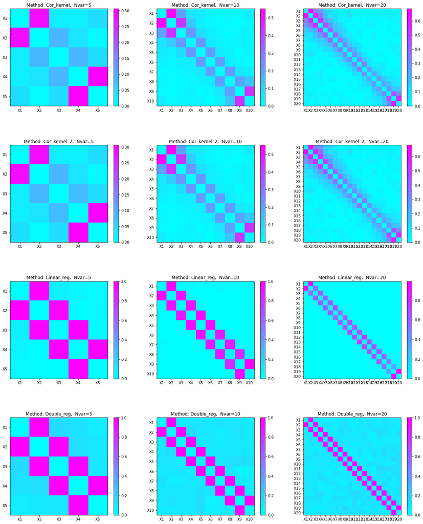

```python
Nvars = [5, 10, 20]
methods = ["Cor_kernel", "Cor_kernel_2", "Linear_reg", "Double_reg"]
plt.figure(figsize=(20,25))
plt.subplots_adjust(wspace=.2, hspace=.4)
for m in range(len(methods)):
    for nvar in range(len(Nvars)):
        plt.subplot(4, 3, nvar+1+3*m)
        result = pd.read_csv("./results/result_markov_method_"+str(m)+"_Nvar_"+str(Nvars[nvar])+".csv", index_col=0)
        plt.imshow(result, cmap='cool', interpolation='nearest')
        plt.colorbar()
        plt.title("Method: "+methods[m]+",  "+"Nvar="+str(Nvars[nvar]))
        plt.xticks(np.arange(Nvars[nvar]), ['X' + str(i) for i in range(1, Nvars[nvar]+1)])
        plt.yticks(np.arange(Nvars[nvar]), ['X' + str(i) for i in range(1, Nvars[nvar]+1)])
plt.show()
```